# Fake News Detection

### Step 3: Data Cleaning and Preprocessing

Cleans the dataset by removing duplicates, standardising text, filtering non-English and inappropriate-length texts (100–1000 words), and eliminating missing values to ensure consistent, relevant, and clean data for analysis.

```r
# Remove duplicate rows
news_data <- news_data[!duplicated(news_data), ]

# Text cleaning
news_data$text <- tolower(news_data$text) %>%
  gsub("\\b\\w{1,2}\\b", "", .) %>%
  gsub("[[:punct:]]", " ", .) %>%
  gsub("[[:digit:]]", " ", .) %>%
  removeWords(stopwords("en")) %>%
  gsub("\\s+", " ", .) %>%
  trimws()

# Remove non-English texts
news_data <- news_data[textcat(news_data$text) == "english", ]

# Remove rows with too short or too long text
news_data$word_count <- sapply(strsplit(news_data$text, "\\s+"), length)
news_data <- news_data[news_data$word_count >= 100 & news_data$word_count <= 1000, ]

# Final check for missing values
news_data <- na.omit(news_data)
```

```r
# Save the cleaned dataset to a CSV file
write.csv(news_data, "cleaned_ISOT_Fake_News_data.csv", row.names = FALSE)

# Provide a download link (in case you're using RMarkdown with Shiny or other web-based setups)
cat("The cleaned dataset has been saved as 'cleaned_ISOT_Fake_News_data.csv'.")
```

```
## The cleaned dataset has been saved as 'cleaned_ISOT_Fake_News_data.csv'.
```

Ensuring the data are cleaned by checking for empty documents

```r
# Ensuring the data are cleaned by checking for empty documents, calculates the total number of rows, examines word count distribution, and provides a data summary for further analysis.

# Check for empty documents
cat("Total number of empty documents: ")
```

```
## Total number of empty documents:
```

```r
sum(nchar(news_data$text) == 0)
```

```
## [1] 0
```

```r
# Calculate the total number of rows in the dataset
cat("\n Total number of rows: ")
```

```
##
##  Total number of rows:
```

```r
total_rows <- nrow(news_data)
total_rows
```

```
## [1] 1764
```

```r
# Check the distribution of word counts
cat("\n The distribution of word counts: \n")
```

```
##
##  The distribution of word counts:
```

```r
summary(news_data$word_count)
```

```
##    Min. 1st Qu.  Median    Mean 3rd Qu.    Max.
##   100.0   183.0   237.0   271.2   324.0   946.0
```

```r
# Check the summary of the data
cat("\n Data Summary: \n")
```

```
##
##  Data Summary:
```

```r
summary(news_data)
```

```
##     title               text             subject              date
##  Length:1764        Length:1764        Length:1764        Length:1764
##  Class :character   Class :character   Class :character   Class :character
##  Mode  :character   Mode  :character   Mode  :character   Mode  :character
##
##
##
##      label          word_count
##  Min.   :0.0000   Min.   :100.0
##  1st Qu.:0.0000   1st Qu.:183.0
##  Median :1.0000   Median :237.0
##  Mean   :0.5414   Mean   :271.2
##  3rd Qu.:1.0000   3rd Qu.:324.0
##  Max.   :1.0000   Max.   :946.0
```

### Step 4: Data Analysis and Exploration

Plot 1: checks label distribution and plots article length distribution, comparing word counts between fake and real news articles for analysis.

```r
# Check the distribution of labels
table(news_data$label)
```

```
##
##   0   1
## 809 955
```

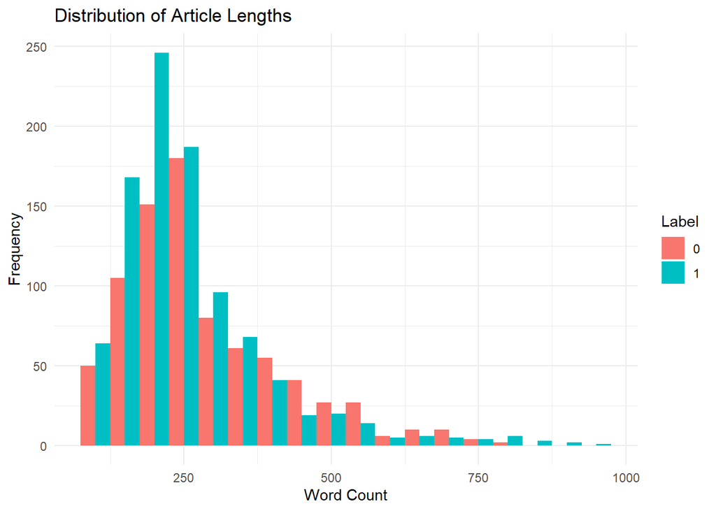

```r
# Plot the distribution of article lengths
ggplot(news_data, aes(x = word_count, fill = as.factor(label))) +
  geom_histogram(binwidth = 50, position = "dodge") +
  labs(title = "Distribution of Article Lengths", x = "Word Count", y = "Frequency", fill = "Label") +
  theme_minimal()
```

Plot 2: Tokenises text into Bigrams, counts their frequency, filters by label, and visualizes the most frequent bigrams for fake and real news.

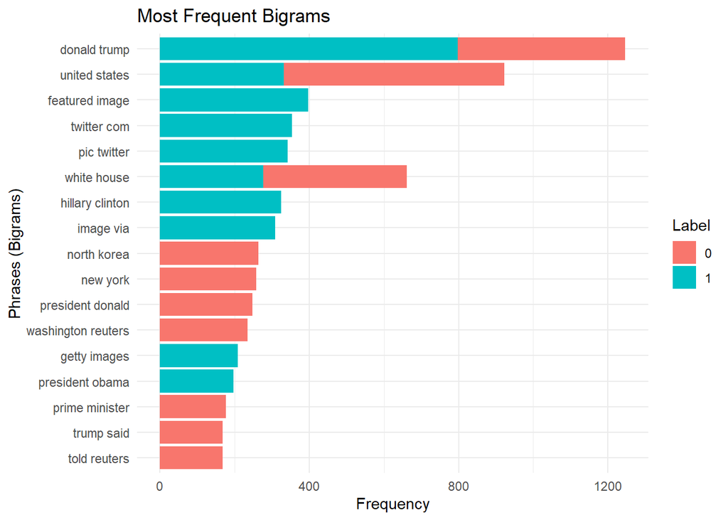

```r
# Tokenise text into bigrams
bigrams <- news_data %>%
  unnest_tokens(bigram, text, token = "ngrams", n = 2)

# Count bigram frequency
bigram_counts <- bigrams %>%
  count(bigram, sort = TRUE)

# Filter by label and plot
bigram_counts <- bigrams %>%
  group_by(label) %>%
  count(bigram, sort = TRUE) %>%
  top_n(10, n)

ggplot(bigram_counts, aes(x = reorder(bigram, n), y = n, fill = as.factor(label))) +
  geom_col() +
  coord_flip() +
  labs(title = "Most Frequent Bigrams", x = "Phrases (Bigrams)", y = "Frequency", fill = "Label") +
  theme_minimal()
```

Plot 3: CalculatesSentiment scores of the articles for each article and visualizes the sentiment distribution for fake and real news using density plots.

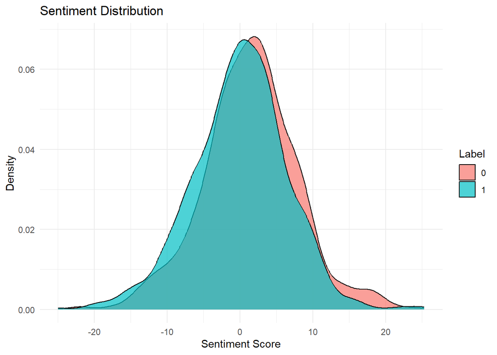

```r
# Calculate sentiment scores
news_data$sentiment <- get_sentiment(news_data$text)

# Visualize sentiment distribution
ggplot(news_data, aes(x = sentiment, fill = as.factor(label))) +
  geom_density(alpha = 0.7) +
  labs(title = "Sentiment Distribution", x = "Sentiment Score", y = "Density", fill = "Label") +
  theme_minimal()
```

Plot 4: This plot visualises the distribution of word counts for fake and real news, highlighting density variations between the two labels.

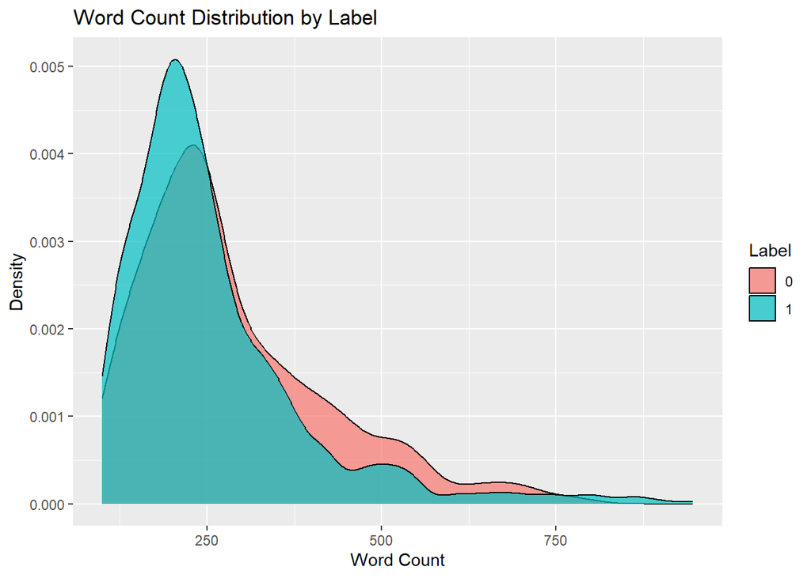

```r
ggplot(news_data, aes(x = word_count, fill = as.factor(label))) +
  geom_density(alpha = 0.7) +
  labs(title = "Word Count Distribution by Label", x = "Word Count", y = "Density", fill = "Label")
```

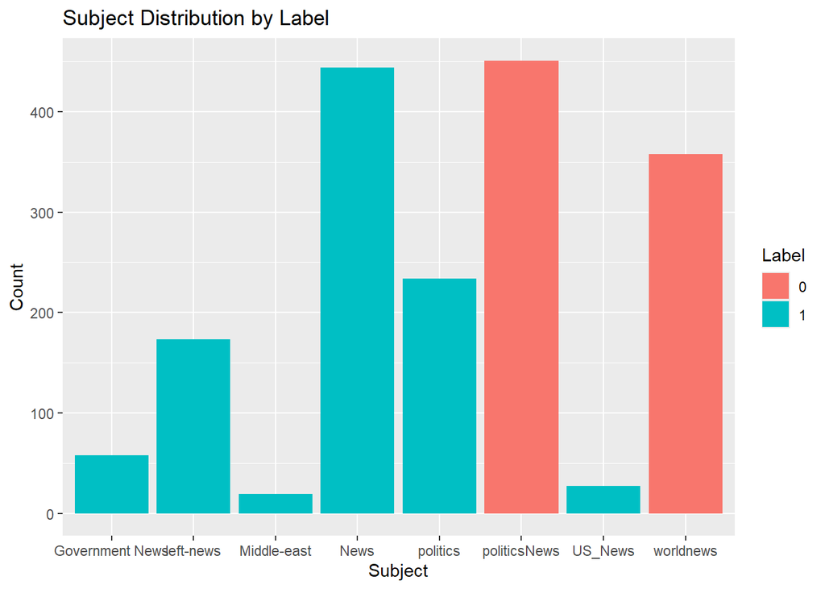

```r
# Bar plot for subject by label
ggplot(news_data, aes(x = subject, fill = as.factor(label))) +
  geom_bar(position = "dodge") +
  labs(title = "Subject Distribution by Label", x = "Subject", y = "Count", fill = "Label")
```

Plot 6: Word clouds were generated for both the article titles and text content, providing an intuitive representation of frequently used words.

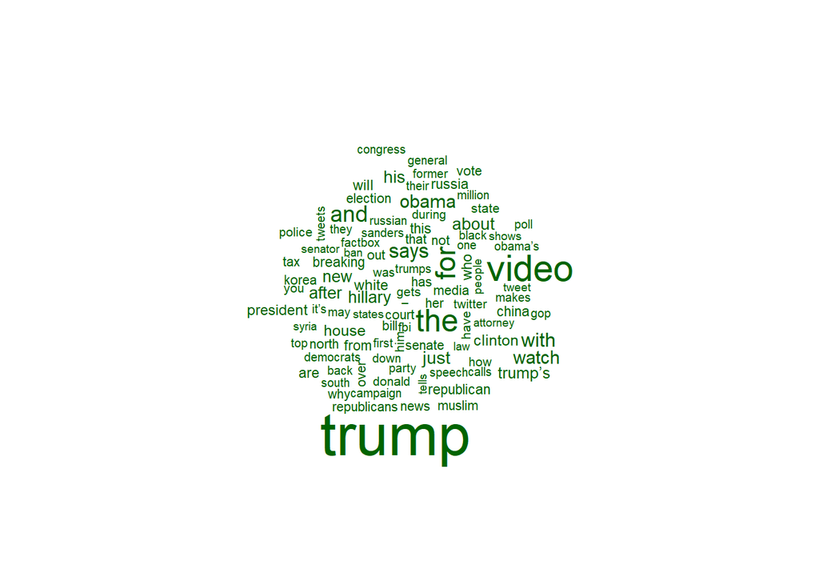

```r
# Create word clouds for title and text
title_text <- paste(news_data$title, collapse = " ")
wordcloud(title_text, max.words = 100, scale = c(3, 0.5), colors = "darkgreen", main = "Title Word Cloud")
```

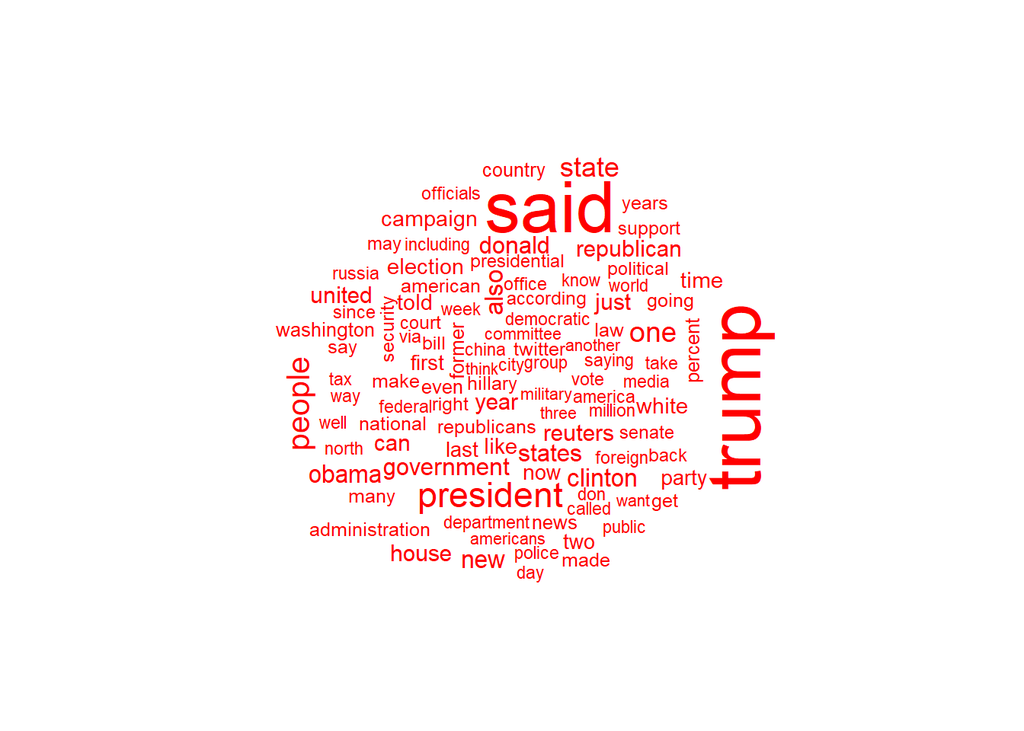

```r
text_text <- paste(news_data$text, collapse = " ")
wordcloud(text_text, max.words = 100, scale = c(3, 0.5), colors = "red", main = "Text Word Cloud")
```

### Step 5: Feature Selection

Finding correlations helps identify relationships between variables, guiding feature selection, improving model accuracy, and uncovering insights for better decision-making in analysis or predictive modeling.

```r
# Compute correlation matrix
numeric_features <- news_data[, c("word_count", "sentiment", "label")]
cor_matrix <- cor(numeric_features)

# Print correlation matrix
print(cor_matrix)
```

```
##             word_count   sentiment      label
## word_count  1.00000000  0.08047516 -0.1099608
## sentiment   0.08047516  1.00000000 -0.1125820
## label      -0.10996076 -0.11258199  1.0000000
```

Document-Term Matrices (DTM) and TF-IDF offer insights into the linguistic patterns of fake versus real news. Ensemble models, in particular, have proven effective in handling the high-dimensional nature of text data while achieving strong classification performance.

```r
# Create a Corpus and Document-Term Matrix (DTM)
corpus <- Corpus(VectorSource(news_data$text))
dtm <- DocumentTermMatrix(corpus)
dtm <- removeSparseTerms(dtm, 0.99)

# Apply TF-IDF
tfidf <- weightTfIdf(dtm)
text_features <- as.data.frame(as.matrix(tfidf))

# Combine TF-IDF features with the label column
data <- cbind(text_features, label = news_data$label)
data <- data.frame(lapply(data, as.numeric))
```

Sparse terms were removed from the document-term matrix to reduce noise. The final dataset incorporated TF-IDF features and the label column for classification.

The cleaned data was converted into a Term Frequency-Inverse Document Frequency (TF-IDF) matrix to represent text data numerically.

```r
# Data Splitting and Preprocessing: Before building predictive models, the dataset will be split into training and testing sets using the createDataPartition function. The training data consisted of 70% of the original dataset, while the remaining 30% was used for testing the model.

# Split data into training and testing sets
set.seed(123)
train_index <- createDataPartition(data$label, p = 0.7, list = FALSE)
train_data <- data[train_index, ]
test_data <- data[-train_index, ]

# Check for missing values in the training and test data
sum(is.na(train_data))
```

```
## [1] 0
```

```r
sum(is.na(test_data))
```

```
## [1] 0
```

Zero-variance features will be removed from both the training and testing sets to ensure a more efficient model training process.

```r
# Identify zero-variance features
zero_var_cols <- nearZeroVar(train_data, saveMetrics = TRUE)

# Remove zero-variance features
train_data <- train_data[, !zero_var_cols$nzv]
test_data <- test_data[, !zero_var_cols$nzv]

# Ensure all columns (except the label) are numeric
train_data <- data.frame(lapply(train_data, as.numeric))
test_data <- data.frame(lapply(test_data, as.numeric))
```

Data Scaling

```r
# Scale the data
train_scale <- scale(train_data[, -ncol(train_data)])
test_scale <- scale(test_data[, -ncol(test_data)])
train_scale <- data.frame(train_scale, label = train_data$label)
test_scale <- data.frame(test_scale, label = test_data$label)
```

The data has been scaled to ensures that features with different units or ranges do not disproportionately affect model performance.

### Step 6: Predictive Modelling Selection and Training

The predictive modeling section involved training two models: * Random Forest * k-Nearest Neighbors (KNN).

*Random Forest Predictive Modelling*

```r
# Train Random Forest model
rf_model <- randomForest(
  x = train_scale[, -ncol(train_scale)],
  y = as.factor(train_scale$label),
  ntree = 50,
  mtry = min(5, ncol(train_scale) - 1),
  importance = TRUE)

rf_pred <- predict(rf_model, test_scale[, -ncol(test_scale)])
```

*KNN Predictive Modelling*

```r
# Train and test KNN model
k <- 5
knn_pred <- knn(
  train = train_scale[, -ncol(train_scale)],
  test = test_scale[, -ncol(test_scale)],
  cl = as.factor(train_scale$label),
  k = k)
```

### Step 7: Model Evaluation

Confusion matrices will be generated for both models to evaluate their performance on the test set.

*Random Forest Predictive Modelling*

```r
# Evaluate Random Forest
rf_conf_matrix <- confusionMatrix(as.factor(rf_pred), as.factor(test_scale$label))
print(rf_conf_matrix)
```

```
## Confusion Matrix and Statistics
##
##           Reference
## Prediction   0   1
##          0 227   9
##          1   5 288
##
##                Accuracy : 0.9735
##                  95% CI : (0.956, 0.9855)
##     No Information Rate : 0.5614
##     P-Value [Acc > NIR] : <2e-16
##
##                   Kappa : 0.9464
##
##  Mcnemar's Test P-Value : 0.4227
##
##             Sensitivity : 0.9784
##             Specificity : 0.9697
##          Pos Pred Value : 0.9619
##          Neg Pred Value : 0.9829
##              Prevalence : 0.4386
##          Detection Rate : 0.4291
##    Detection Prevalence : 0.4461
##       Balanced Accuracy : 0.9741
##
##        'Positive' Class : 0
##
```

*KNN Predictive Modelling*

```r
# Evaluate KNN
knn_conf_matrix <- confusionMatrix(as.factor(knn_pred), as.factor(test_scale$label))
print(knn_conf_matrix)
```

```
## Confusion Matrix and Statistics
##
##           Reference
## Prediction   0   1
##          0 227 124
##          1   5 173
##
##                Accuracy : 0.7561
##                  95% CI : (0.7172, 0.7922)
##     No Information Rate : 0.5614
##     P-Value [Acc > NIR] : < 2.2e-16
##
##                   Kappa : 0.5311
##
##  Mcnemar's Test P-Value : < 2.2e-16
##
##             Sensitivity : 0.9784
##             Specificity : 0.5825
##          Pos Pred Value : 0.6467
##          Neg Pred Value : 0.9719
##              Prevalence : 0.4386
##          Detection Rate : 0.4291
##    Detection Prevalence : 0.6635
##       Balanced Accuracy : 0.7805
##
##        'Positive' Class : 0
##
```

## Step 8: Hyperparameter Tuning

Hyperparameter tuning was conducted for KNN to identify the optimal number of neighbors (k) that maximised accuracy.

```r
# Tune KNN
k_values <- seq(1, 20, by = 2)
accuracy_values <- numeric(length(k_values))

for (i in seq_along(k_values)) {
  k <- k_values[i]
  knn_pred <- knn(
    train = train_scale[, -ncol(train_scale)],
    test = test_scale[, -ncol(test_scale)],
    cl = as.factor(train_scale$label),
    k = k
  )
  accuracy_values[i] <- confusionMatrix(as.factor(knn_pred), as.factor(test_scale$label))$overall['Accuracy']
}

# Find the best K
best_k <- k_values[which.max(accuracy_values)]
cat("Best K value:", best_k, "\n")
```

```
## Best K value: 5
```

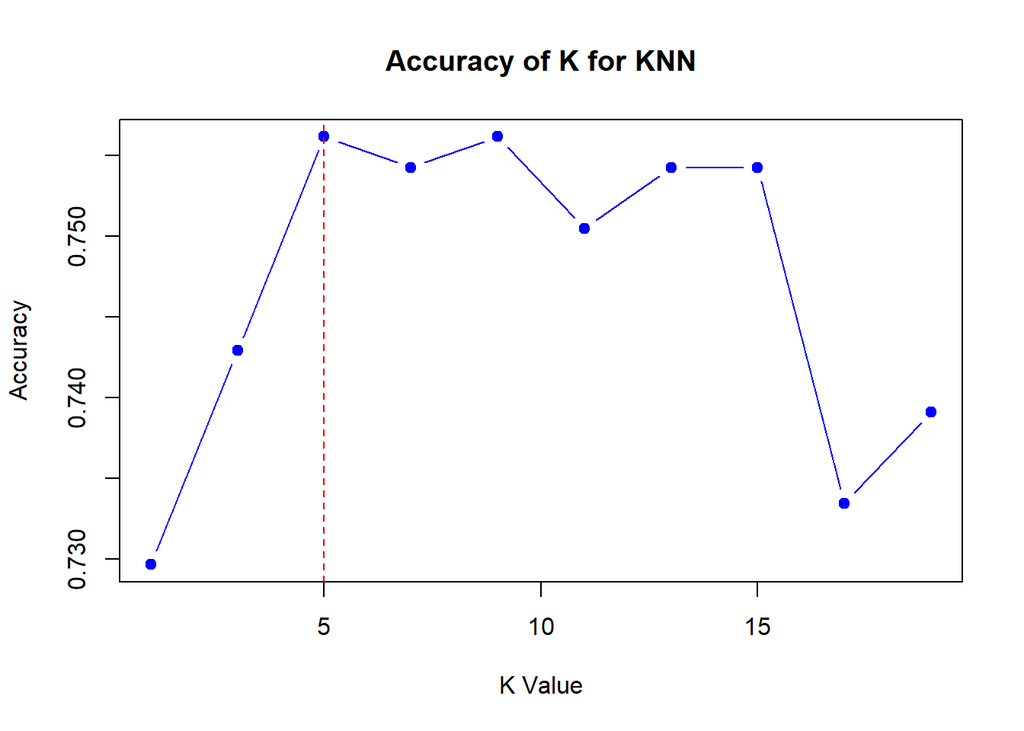

```r
# Plot accuracy of K value
plot(k_values, accuracy_values, type = "b", col = "blue", pch = 19,
     xlab = "K Value", ylab = "Accuracy",
     main = "Accuracy of K for KNN")
abline(v = best_k, col = "red", lty = 2)
```

## Model Comparison

Accuracy of both predictive models

```r
cat("Random Forest Accuracy:", rf_conf_matrix$overall['Accuracy'], "\n")
```

```
## Random Forest Accuracy: 0.973535
```

```r
cat("KNN Accuracy with K =", k, ":", knn_conf_matrix$overall['Accuracy'], "\n")
```

[output not shown]

# Dataset Two: WEL Fake News Classification

### Step 1: Define Problem Statement

The ability to sharefake news on social media and digital platforms has led to significant challenges to the dissemination of accurate information. The problem addressed in this report is classifying news articles as fake or real. The research aims to build predictive models that are able to classify news articles as fake or real news based on their textual data. The dataset used for this analysis is the WELFake dataset, which contains labelled news articles classified as “fake” or “real” for training and testing the predictive model.

Machine learning techniques to be used for this dataset are: *Logistic Regression, Support Vector Machines (SVM)*, due to their ability to highlight the and classify news articles by applying data preprocessing, feature selection, and model evaluation to achieve high classification accuracy for the textual contents.

### Step 2: Data Source

Load news datasets and call it (data), and sample 5% of the dataset for faster loading and efficient processing using random selection.

```r
# Load the dataset
data <- read.csv("E:\\AI and Data Sience\\Year 2\\Applied Predictive Modelling\\Assignment\\EMAD_ALKADRO_23646017\\WELFake_Dataset\\WELFake_Dataset.csv")

# Use Sample 5% of the dataset for faster processing
set.seed(123)
data <- data %>% sample_frac(0.05)
```

Displays the first five rows of the dataset to preview its structure and content without showing execution results on the R report document.

```r
# Display the merged dataset
head(data, 5)
```

### Step 3: Data Cleaning and Preprocessing

Cleans the dataset by removing duplicates, standardising text, filtering non-English, and eliminating missing values to ensure consistent, relevant, and clean data for analysis.

```r
# Remove duplicate rows
data <- data[!duplicated(data), ]

# Text cleaning
data$text <- tolower(data$text) %>%
  gsub("\\b\\w{1,2}\\b", "", .) %>%
  gsub("[[:punct:]]", " ", .) %>%
  gsub("[[:digit:]]", " ", .) %>%
  removeWords(stopwords("en")) %>%
  gsub("\\s+", " ", .) %>%
  trimws()

# Remove non-English texts
data <- data[textcat(data$text) == "english", ]

# Final check for missing values
data <- na.omit(data)
```

```r
# Save the cleaned dataset to a CSV file
write.csv(data, "cleaned_WELFake_News_data.csv", row.names = FALSE)

# Provide a download link (in case you're using RMarkdown with Shiny or other web-based setups)
cat("The cleaned dataset has been saved as 'cleaned_news_WELFake_News_data.csv'.")
```

[output not shown]

```r
# Check for empty documents
cat("Total number of empty documents: ")
```

```
## Total number of empty documents:
```

```r
sum(nchar(data$text) == 0)
```

```
## [1] 0
```

```r
# Calculate the total number of rows in the dataset
cat("\n Total number of rows: ")
```

```
##
##  Total number of rows:
```

```r
total_rows <- nrow(data)
total_rows
```

```
## [1] 3487
```

```r
# Check the distribution of word counts
cat("\n The distribution of word counts: \n")
```

```
##
##  The distribution of word counts:
```

```r
summary(data$word_count)
```

```
## Length  Class   Mode
##      0   NULL   NULL
```

```r
# Check the summary of the data
cat("\n Data Summary: \n")
```

```
##
##  Data Summary:
```

```r
summary(data)
```

```
##        X            title               text               label
##  Min.   :    4   Length:3487        Length:3487        Min.   :0.000
##  1st Qu.:17716   Class :character   Class :character   1st Qu.:0.000
##  Median :35584   Mode  :character   Mode  :character   Median :1.000
##  Mean   :35805                                         Mean   :0.501
##  3rd Qu.:53975                                         3rd Qu.:1.000
##  Max.   :72054                                         Max.   :1.000
```

### Step 4: Data Analysis and Exploration

Create all the required plots to analyse the data and understand the type of feature needed.

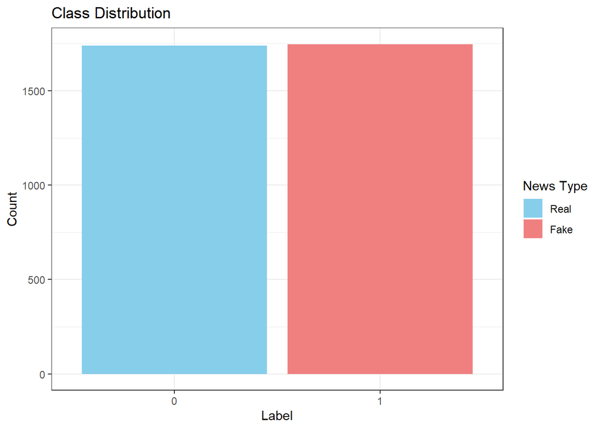

```r
# Plot 1: Label distribution
ggplot(data, aes(x = as.factor(label), fill = as.factor(label))) +
  geom_bar() +
  scale_fill_manual(values = c("0" = "skyblue", "1" = "lightcoral"), labels = c("Real", "Fake")) +
  labs(title = "Class Distribution", x = "Label", y = "Count", fill = "News Type") +
  theme_bw()
```

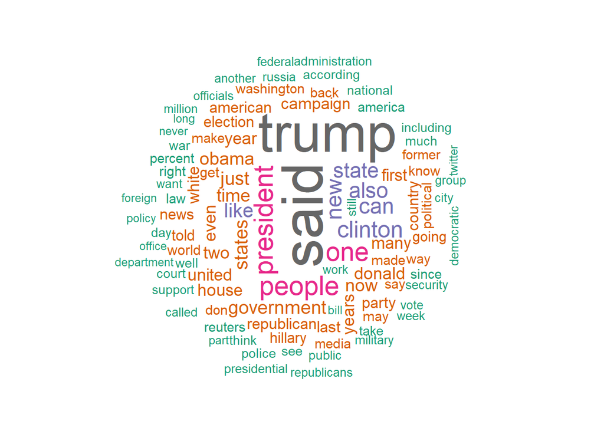

```r
# Plot 2: Word cloud for text
wordcloud(data$text, max.words = 100, random.order=FALSE, colors=brewer.pal(8, "Dark2"))
```

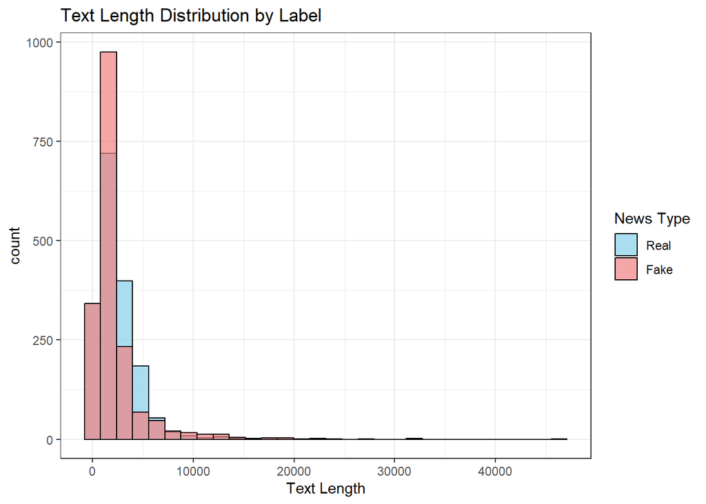

```r
# Add label difference to text length distribution
data <- data %>%
  mutate(text_length = nchar(text), title_length = nchar(title))

# Plot: Text length distribution by label
ggplot(data, aes(x = text_length, fill = as.factor(label))) +
  geom_histogram(bins = 30, alpha = 0.7, position = "identity", color = "black") +
  scale_fill_manual(values = c("0" = "skyblue", "1" = "lightcoral"),
                    labels = c("Real", "Fake")) +
  ggtitle("Text Length Distribution by Label") +
  labs(x = "Text Length", fill = "News Type") +
  theme_bw()# Add label difference to text length distribution
```